# Introduction to R - Day 2

Manny Gimond

Summer 2019

> Before working through this exercise, download the SP1819.xlsx and Divisions.csv files into your project folder.

## Extending R’s functionality with packages

While R has a rich suite of functions to work off of, the R community extends on R’s built-in functions by offering customized functions via packages. There are more than 14,000 packages with additional packages being added weekly or daily. Most packages can be downloaded via CRAN (the Comprehensive R Archive Network). Packages are installed in your local user profile. You can install packages by command line via `install.packages`. In today’s workshop, we’ll make use of five packages: `readxl`, `dplyr`, `stringr`, `writexl` and `ggplot2`.

```r
install.packages(c("readxl", "dplyr", "stringr", "writexl", "ggplot2" ))
```

Downloading packages from CRAN is a one time operation. Once installed on your computer, you do not need to re-install them.

## Reading Excel files

Installing packages onto your computer does not mean that their functions are instantly available for use in an R session. You need to explicitly tell R which packages are to be used to perform a specified set of tasks.

In this next exercise, we will load the `readxl` package into our current R session using the `library()` function.

```r
library(readxl)
```

The `readxl` packages contain a function, `read_excel`, that will allow us to load an Excel file. In this next code chunk, we’ll read the same spring course list loaded yesterday but this time we’ll load it as an excel file.

```r
dat <- read_excel("SP1819.xlsx", sheet = "sheet1")
```

```r
str(dat)
```

```
Classes 'tbl_df', 'tbl' and 'data.frame':   717 obs. of  13 variables:
 $ Course   : chr  "AA118" "AA223" "AA223" "AA231" ...
 $ Section  : chr  "A" "A" "A" "A" ...
 $ Cr       : chr  "2" "4" "4" "4" ...
 $ Days     : chr  "TR" "TR" "TR" "MW" ...
 $ Times    : chr  "2:30pm- 4:00pm" "8:00am- 9:30am" "9:45am-10:45am" "11:00am-12:15pm" ...
 $ Title    : chr  "Dance Technique Lab: Dance Forms of the African Diaspora: Hip-hop (See TD118)" "Critical Race Feminisms and Tap Dance (See WG223)" "Critical Race Feminisms and Tap Dance (See WG223)" "Caribbean Cultures (See AY231)" ...
 $ DistReq  : chr  NA "A" "A" NA ...
 $ Diversity: chr  NA "U" "U" "I" ...
 $ Room     : chr  NA NA NA NA ...
 $ Reg      : num  0 0 0 0 0 0 0 0 0 0 ...
 $ Max      : num  NA NA NA NA NA NA NA NA NA NA ...
 $ Exam     : num  NA NA NA NA NA NA NA NA NA NA ...
 $ Faculty  : chr  "Akuchu" "Thomas, S" "Thomas, S" "Bhimull" ...
```

## Manipulating data tables

While base R is certainly capable of satisfying most data table manipulation needs, the `dplyr` and `stringr` packages (part of a set of packages called the `tidyverse`) provide a consistent and user friendly platform for working with data tables.

### Subsetting data table by row

First, we’ll load the `dplyr` package.

```r
library(dplyr)
```

Next, we’ll subset the spring courses schedule by keeping just those rows whose `Days` column equals `M`. Note that R is case sensitive so be sure to specify uppercase `M` and *not* lower case `m`.

```r
dat1 <- dat %>%
  filter(Days == "M")
```

It’s best to picture the data manipulation workflow as an assembly line where the data table is being *piped* from one station to another where each station is performing an operation on the data table. Here, the *piping* operator is assigned the `%>%` glyph–its shortcut key is `ctrl+shift+M` (or `command+shift+M` on a Mac). The `filter()` function is a *station* along the assembly line that subsets the table by row based on the condition that the value in the `Days` column equals `M`. The output of this operation is then passed to a new data table object called `dat1`.

We can apply multiple conditions to the `filter` function by piecing the conditions with boolean operators. For example, to filter the table by rows where `Days` equals `M` and where `Reg` is greater than `16`, type:

```r
dat1 <- dat %>%
  filter(Days == "M" & Reg > 16)
```

Here, since both conditions *must* be met, we tie these conditions together with the boolean **AND**, `&`. You can also write the above as:

```r
dat1 <- dat %>%
  filter(Days == "M",  Reg > 16)
```

Here, the comma `,` implies that each condition *must* be met.

Another boolean operator you might find yourself using is the **OR** , `|`, operator. For example, if you want to filter by rows where `Days` equals `M` OR `MW`, type:

```r
dat1 <- dat %>%
  filter(Days == "M" | Days == "MW")
```

When combined with the `Reg` condition, we get:

```r
dat1 <- dat %>%
  filter(Days == "M" | Days == "MW",
         Reg > 16)
```

It’s good practice to split the different conditions across multiple lines to facilitate readability.

### Subsetting data table by column

Using the same piping operation framework, we can subset our table by column names. For example, to limit the table to the columns `Course`, `Days`, `Times` and `Reg`, type:

```r
dat1 <- dat %>%
  select(Course, Days, Times, Reg)
```

We can, of course, combine data table operations. For example, to combine the row selection operation with this column selection operation, type:

```r
dat1 <- dat %>%
  select(Course, Days, Times, Reg) %>%
  filter(Days == "M" | Days == "MW",
         Reg > 16)
```

Be careful with the order in which the operations are written out. For example, had we chosen not to keep the `Days` column in the final output, the following would have generated an error message.

```r
dat1 <- dat %>%
  select(Course, Times, Reg) %>%
  filter(Days == "M" | Days == "MW",
         Reg > 16)
```

```
Error in ~Days == "M" | Days == "MW": object 'Days' not found
```

Going back to our assembly line metaphor, the `filter` station only sees what’s being passed to it (here, a subset of the original table with the omitted `Days` column). So in this example, the order in which the operations takes place matters. The `filter` operation should be placed before the columns selection operation as in:

```r
dat1 <- dat %>%
    filter(Days == "M" | Days == "MW",
           Reg > 16) %>%
    select(Course, Times, Reg)
```

### Summarizing table columns

The simplest summary is the count. For example, we can extract the total number of rows in the output table using the `count()` function:

```r
dat %>%
  select(Course, Days, Times, Reg) %>%
  filter(Days == "M" | Days == "MW",
         Reg > 16) %>%
  count()
```

```
# A tibble: 1 x 1
      n
  <int>
1    36
```

We can also summarize columns using descriptive statistics such as the mean, minimum and maximum. Next, we’ll make use of the `summarise()` function. For example:

```r
dat %>%
  select(Course, Days, Times, Reg) %>%
  filter(Days == "M" | Days == "MW",
         Reg > 16) %>%
  summarise(mean_reg = mean(Reg), max_reg = max(Reg))
```

```
# A tibble: 1 x 2
  mean_reg max_reg
     <dbl>   <dbl>
1     26.3     100
```

Here, the `summarise` function generates two columns named `mean_reg` and `max_reg`. These are names we’ve chosen. The functions that perform the actual statistical summaries are `mean()` and `max()`.

Sometimes, the data table may contain missing values (denoted as `NA`). This can be problematic when computing a statistical summary.

```r
mean(c(34.2, 4, NA, 100))
```

```
[1] NA
```

If an `NA` is present in a vector, the `mean()` function will return `NA`. To have the `mean()` function ignore the `NA`s, simply add the argument `na.rm = TRUE` to the function.

```r
mean(c(34.2, 4, NA, 100), na.rm = TRUE)
```

```
[1] 46.06667
```

This fix applies to other statistical functions such as `min()`, `max()` and `median()`

### Getting row counts by grouped values

We can instruct R to break down summaries by unique column values. For example, to break down the summary statistics by unique `Days` values (there are only two: `M` and `MW`), add the `group_by()` function before calling the `summarise()` function.

```r
dat %>%
  select(Course, Days, Times, Reg) %>%
  filter(Days == "M" | Days == "MW",
         Reg > 16) %>%
  group_by(Days) %>%
  summarise(mean_reg = mean(Reg), max_reg = max(Reg))
```

```
# A tibble: 2 x 3
  Days  mean_reg max_reg
  <chr>    <dbl>   <dbl>
1 M         19.8      25
2 MW        28.8     100
```

### Splitting a column into multiple columns

In this next exercise, we will split the course number into its program/department two letter designation and its numeric component. These values will be assigned to two new columns that we’ll name `Dept` and `Number`. Here, we’ll make use of the `stringr` package which has a rich set of character manipulating functions.

```r
library(stringr)
dat1 <- dat %>%
  select(Course, Days, Times, Reg) %>%
  filter(Days == "M" | Days == "MW",
         Reg > 16) %>%
  mutate(Dept = str_sub(Course, start = 1, end = 2),
         Number = str_sub(Course, start = 3, end = 5),
         Number = as.integer(Number))
```

We make use of the `mutate()` function to create the two new columns. We also make use of the `str_sub()` function to extract characters based on their position in the string. The position values are inclusive.

Note that the output of `str_sub` is always a character data type. This does not make sense for the `Number` variable. We therefore coerce it into an integer by replacing it with its numeric representation.

### Joining tables

Next, we will load another table: `Divisions.csv`.

```r
div <- read.csv("Divisions.csv", stringsAsFactors = FALSE)
div
```

```
                    Division DeptProg
1                 Humanities       AR
2                 Humanities       CL
3                 Humanities       EA
4                 Humanities       EN
5                 Humanities       FR
6                 Humanities       IT
7                 Humanities       GM
8                 Humanities       RU
9                 Humanities       MU
10                Humanities       PL
11                Humanities       RE
12                Humanities       SP
13                Humanities       TD
14                Humanities       JA
```

[output cut: 29 more lines]

The `div` table consists of the departments’ two letter designation and their affiliated division. We want to add the division names to each course in the `dat1` table. To do this, we’ll join the contents of the `div` table to the `dat1` table by matching column values: the `Depth` column from the `dat1` table will be matched to the `DeptProg` column from the `div` table.

```r
dat1 <- dat %>%
  select(Course, Days, Times, Reg) %>%
  filter(Days == "M" | Days == "MW",
         Reg > 16) %>%
  mutate(Dept = str_sub(Course, start = 1, end = 2),
         Number = str_sub(Course, start = 3, end = 5),
         Number = as.integer(Number)) %>%
  left_join(div, by = c("Dept" = "DeptProg"))
```

Let’s check the first few lines of `dat1`.

```r
head(dat1)
```

```
# A tibble: 6 x 7
  Course  Days  Times             Reg Dept  Number Division
  <chr>   <chr> <chr>           <dbl> <chr>  <int> <chr>
1 AR112   MW    11:00am-12:15pm    25 AR       112 Humanities
2 AR135   MW    2:00pm- 3:50pm     18 AR       135 Humanities
3 AY231   MW    11:00am-12:15pm    17 AY       231 Social Sciences
4 CH142 L M     1:00pm- 3:50pm     20 CH       142 Natural Sciences
5 CH147 L M     1:00pm- 4:00pm     17 CH       147 Natural Sciences
6 CI142   MW    11:00am-12:15pm    19 CI       142 Interdisciplinary Studies
```

## Saving a data table to file

To write a data table to a CSV file, type:

```r
write.csv(dat1, file = "spring_subset.csv")
```

To write the data table to an Excel file, type:

```r
library(writexl)
write_xlsx(dat1, path = "spring_subset.xlsx")
```

## Visualizing data

A popular and very versatile plotting environment is the `ggplot2` package. We’ll therefore load this package into our R session.

```r
library(ggplot2)
```

### Bar plot

Before we generate a bar plot of course counts by division (from the data subset `dat1`), we’ll summaries the data by `Division`.

```r
dat2 <- dat1 %>%
  group_by(Division) %>%
  count()
```

Next, we’ll piece together the `ggplot2` functions to generate the bar plot.

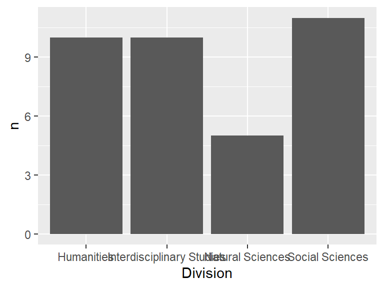

```r
ggplot(dat2, aes(x = Division, y = n)) + geom_bar(stat = "identity")
```

The first function, `ggplot()`, specifies the data table and the variables that will be mapped to the plot window. The `aes()` function instructs R to map the `Division` column to the x-axis and the `n` column to the y-axis. The next function, `geom_bar()`, specifies the geometry to be used to visualize the data. Its argument, `stat = "identity"` simply indicates that the values already represent counts.

We can flip the axes by adding `coord_flip()` to the code chunk.

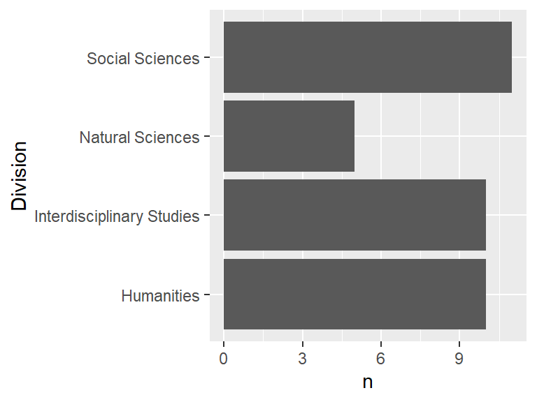

```r
ggplot(dat2, aes(x = Division, y = n)) + geom_bar(stat = "identity") +
  coord_flip()
```

We may also opt to reorder the divisions by count values. This requires wrapping the `Division` variable with the `reorder()` function which takes, as a second argument, the numeric variable `n` to be used to reorder the divisions.

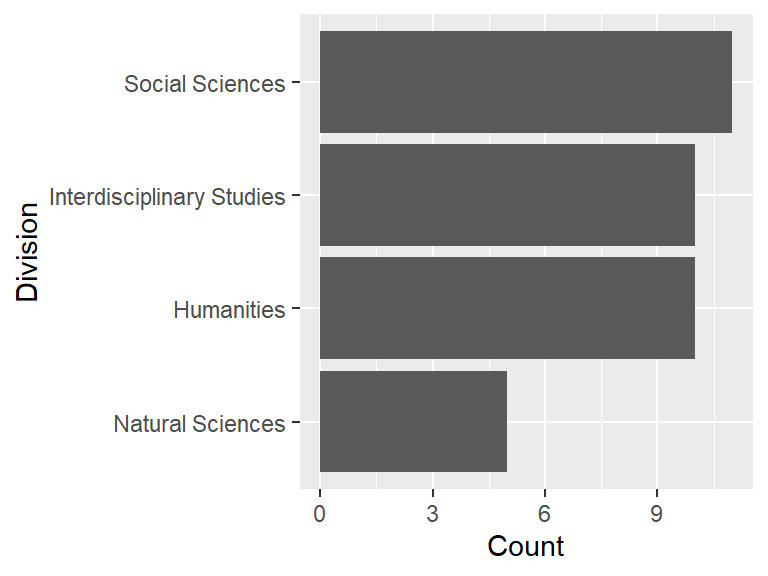

```r
ggplot(dat2, aes(x = reorder(Division, n), y = n)) +
  geom_bar(stat = "identity") + coord_flip() +
  xlab("Division") + ylab("Count")
```

### Histogram

In this example, we’ll generate a histogram of registration values from the original courses data file, `dat`.

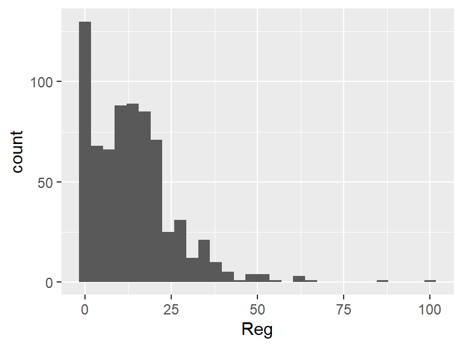

```r
ggplot(dat, aes(x = Reg)) + geom_histogram()
```

### Scatter plot

In this next example, we’ll work off of `dat1` and two of its variables (`Number` and `Reg`) to generate a scatter plot.

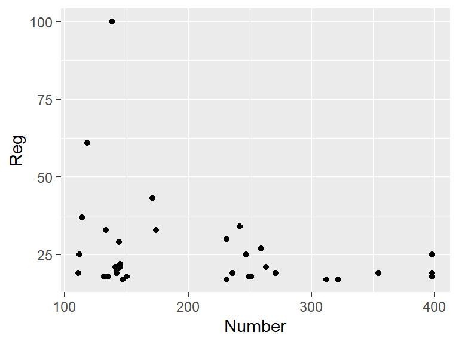

```r
ggplot(dat1, aes(x = Number, y = Reg)) + geom_point()
```

### Faceting plots

You can also break the plots down into sub-plots based on a categorical variable. For example, to generate a histogram of class sizes by division, type:

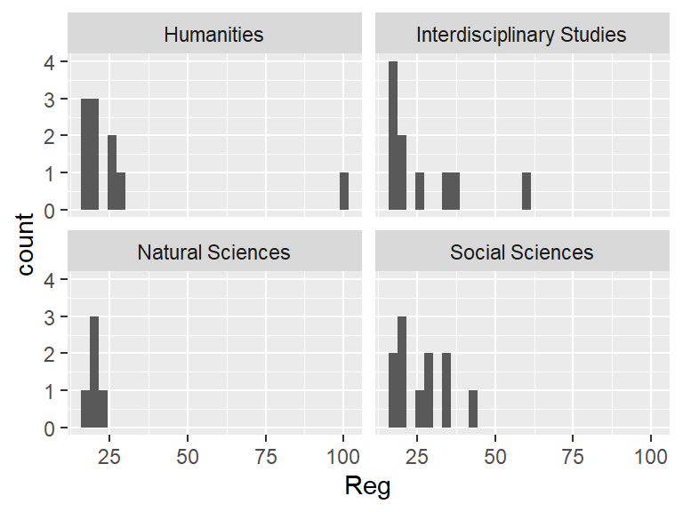

```r
ggplot(dat1, aes(x = Reg)) + geom_histogram() + facet_wrap(~ Division)
```

The `facet_wrap()` function instructs `ggplot` to break the histogram plots into separate plots based on the unique `Division` values (there are four in our example) associated with each record in `dat1`.

# Additional resources

- For a thorough coverage of data table manipulation operations see https://mgimond.github.io/ES218/Week03a.html
- For additional examples on grouping and summarizing, see https://mgimond.github.io/ES218/Week03ab_groupby.html
- A large selection of `ggplot2` examples can be found here: https://mgimond.github.io/ES218/Week04c.html
- If you want to post questions to the global R user community, https://community.rstudio.com/ offers a very welcoming environment.
- To stay abreast of the latest R packages or online resources, visit https://rweekly.org/